# Resultados

Gabriel Rodrigues

2022-10-14

Esse arquivo utilizará os microdados_filtrados, que foram gerados no script “tratamento_de_dados.R”

### Importando pacotes gráficos

```r
library(ggplot2)
library(hrbrthemes)
library(tidyverse)
library(RColorBrewer)
library(readr)
library(dplyr)
library(viridis)
```

### Importando dados

```r
microdados_filtrados <- read_csv("DADOS/microdados_filtrados.csv")

#Microdados sem NAs

microdados_sem_NA <- na.omit(microdados_filtrados)
```

# Respondendo perguntas do arquivo “planejamento_da_analise”:

## Qual a proporção entre participantes homens e mulheres?

```r
microdados_filtrados %>% count(TP_SEXO)
```

```
## # A tibble: 2 × 2
##   TP_SEXO       n
##   <chr>     <int>
## 1 F       3031760
## 2 M       2063411
```

Agora dividindo o número de cada grupo pelo total, podemos obter a porcentagem de participação:

```r
3031760/5095171*100
```

```
## [1] 59.50262
```

```r
2063411/5095171*100
```

```
## [1] 40.49738
```

### Porcentagem dos pariticipantes inscritos = 59.5% de mulheres e 40.5% de homens.

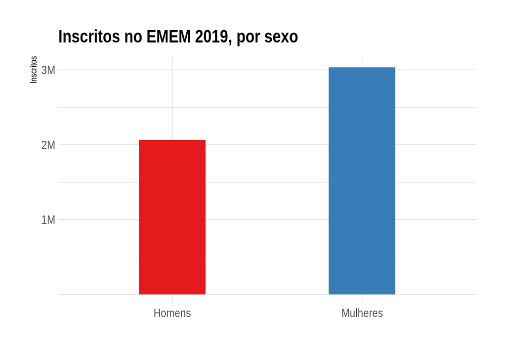

## Qual a proporção entre participantes de diferentes raças?

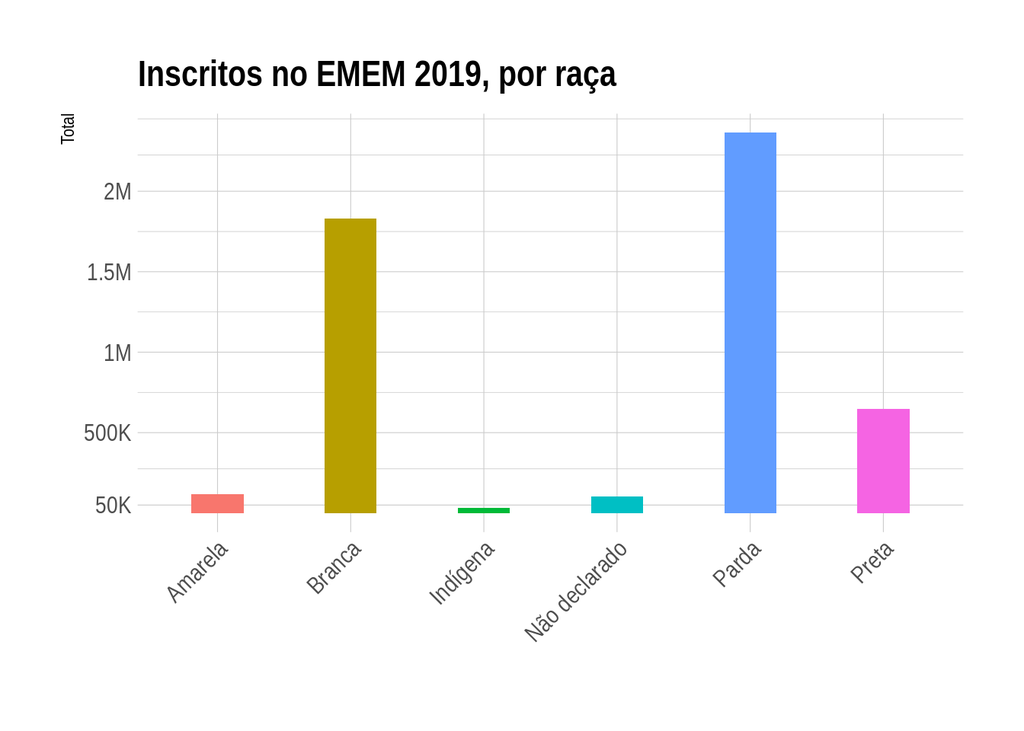

## Qual o estado civil declarado pelos inscritos?

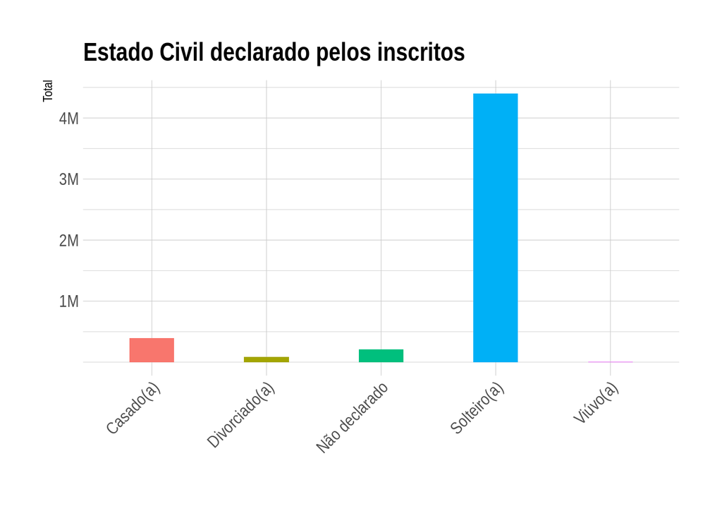

## Quantos particiantes já concluíram o ensino médio? quantos ainda estão fazendo? E quantos não fizeram?

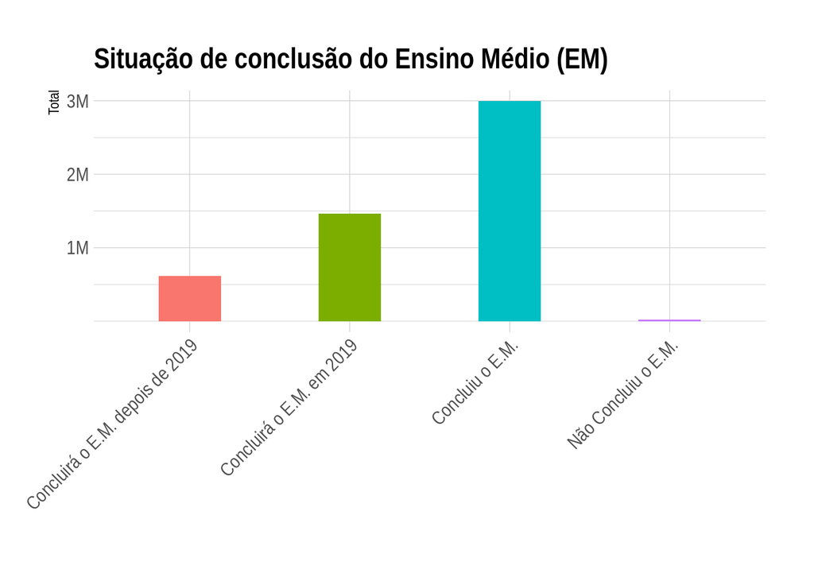

## Dos participantes que já conluíram o ensino médio, qual a distribuição do ano de conclusão?

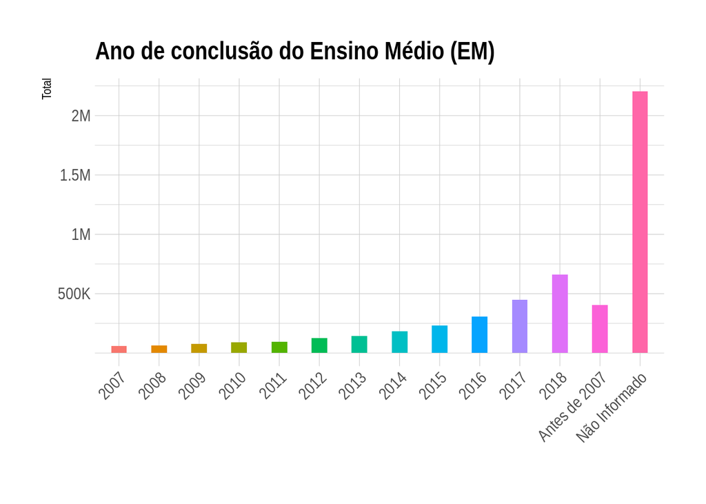

## Qual foi o percentual de presença nas provas objetivas?

```r
# Porcentagem de presença:

porcentagem_presenca <- nrow(microdados_sem_NA)/nrow(microdados_filtrados)*100
porcentagem_presenca
```

```
## [1] 41.60958
```

## Quais foram as médias das notas nas provas objetivas?

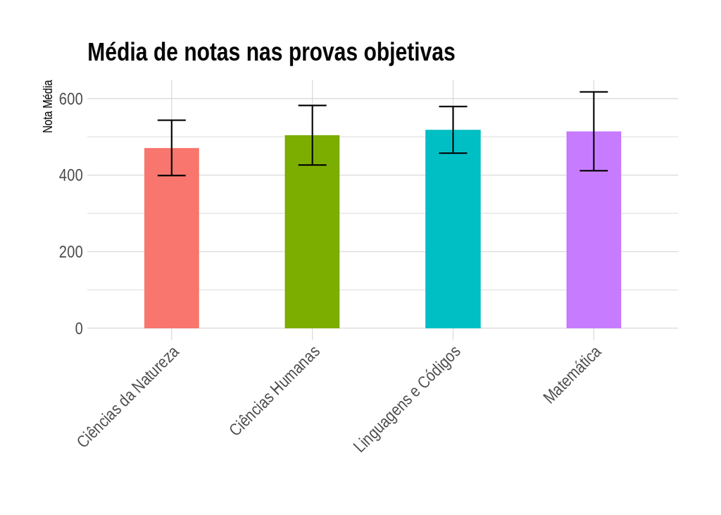

## Quais unidades da federação obtiveram as maiores notas?

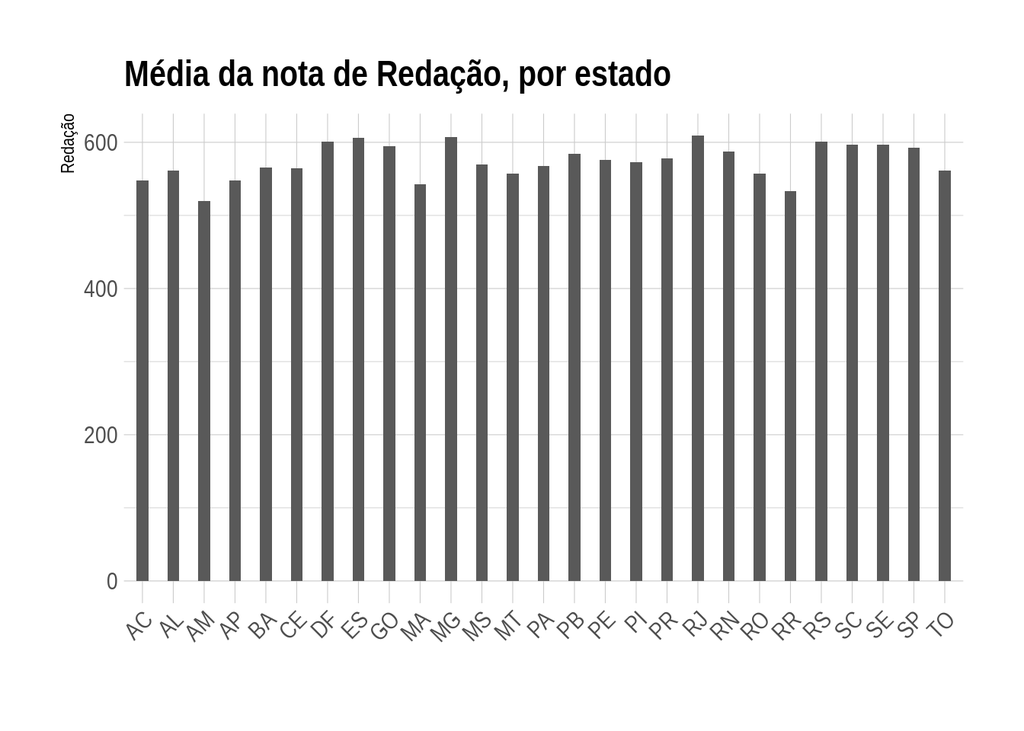

## Qual foi a nota média da prova de redação?

```r
redacao_media <- mean(microdados_sem_NA$NU_NOTA_REDACAO)
redacao_media
```

```
## [1] 580.6354
```

## Qual competência da redação apresentou a menor média de notas, qual apresentou a maior?

```
##            [,1]
## COMP1 121.52994
## COMP2 124.82886
## COMP3 116.47175
## COMP4 123.58516
## COMP5  94.21966
```

## Apresentar os níveis diferentes de educação dos pais entre os candidatos.

#### B - Não completou a 4ª série/5º ano do Ensino Fundamental.

#### C - Completou a 4ª série/5º ano, mas não completou a 8ª série/9º ano do Ensino Fundamental.

#### D - Completou a 8ª série/9º ano do Ensino Fundamental, mas não completou o Ensino Médio.

#### E - Completou o Ensino Médio, mas não completou a Faculdade.

#### F - Completou a Faculdade, mas não completou a Pós-graduação.

#### G - Completou a Pós-graduação.

#### H - Não sei.

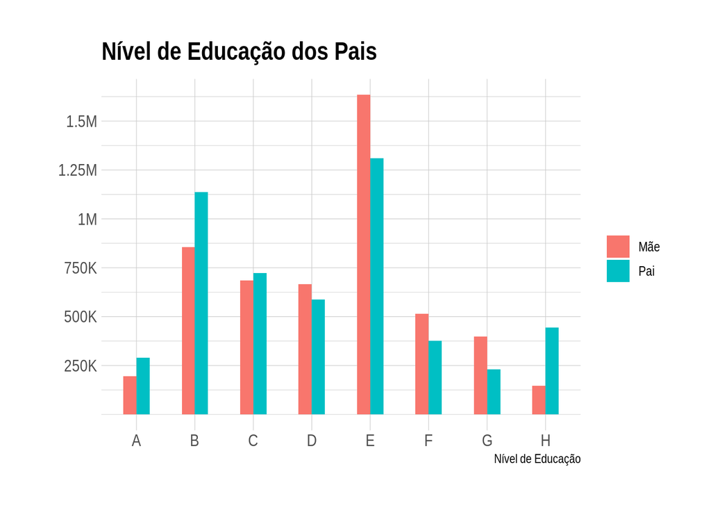

## Qual a ocupação dos pais dos participantes?

#### A - Grupo 1: Lavrador, agricultor sem empregados, bóia fria, criador de animais (gado, porcos, galinhas, ovelhas, cavalos etc.), apicultor, pescador, lenhador, seringueiro, extrativista.

#### B - Grupo 2: Diarista, empregado doméstico, cuidador de idosos, babá, cozinheiro (em casas particulares), motorista particular, jardineiro, faxineiro de empresas e prédios, vigilante, porteiro, carteiro, office-boy, vendedor, caixa, atendente de loja, auxiliar administrativo, recepcionista, servente de pedreiro, repositor de mercadoria.

#### C - Grupo 3: Padeiro, cozinheiro industrial ou em restaurantes, sapateiro, costureiro, joalheiro, torneiro mecânico, operador de máquinas, soldador, operário de fábrica, trabalhador da mineração, pedreiro, pintor, eletricista, encanador, motorista, caminhoneiro, taxista.

#### D - Grupo 4: Professor (de ensino fundamental ou médio, idioma, música, artes etc.), técnico (de enfermagem, contabilidade, eletrônica etc.), policial, militar de baixa patente (soldado, cabo, sargento), corretor de imóveis, supervisor, gerente, mestre de obras, pastor, microempresário (proprietário de empresa com menos de 10 empregados), pequeno comerciante, pequeno proprietário de terras, trabalhador autônomo ou por conta própria.

#### E - Grupo 5: Médico, engenheiro, dentista, psicólogo, economista, advogado, juiz, promotor, defensor, delegado, tenente, capitão, coronel, professor universitário, diretor em empresas públicas ou privadas, político, proprietário de empresas com mais de 10 empregados.

#### F - Não sei.

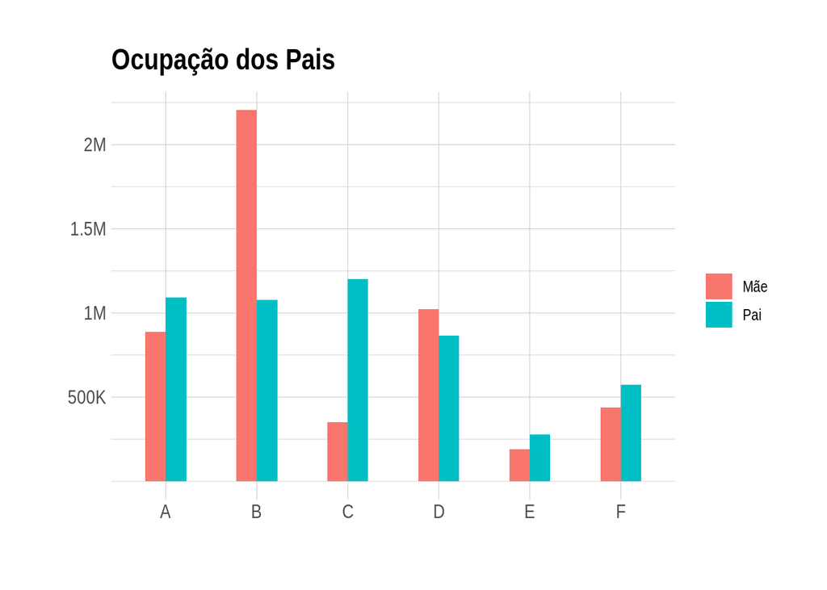

## Comparar a classe de trabalho dos pais de participantes de diferentes raças.

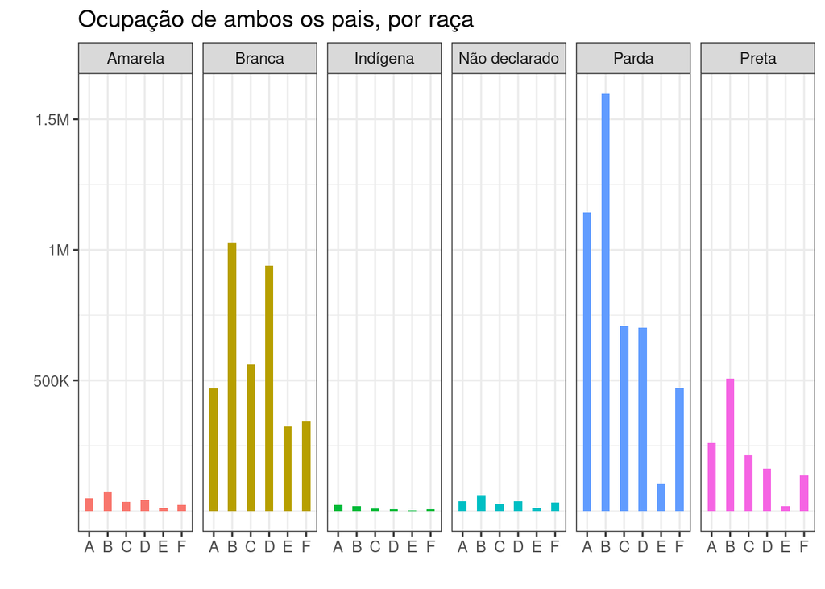

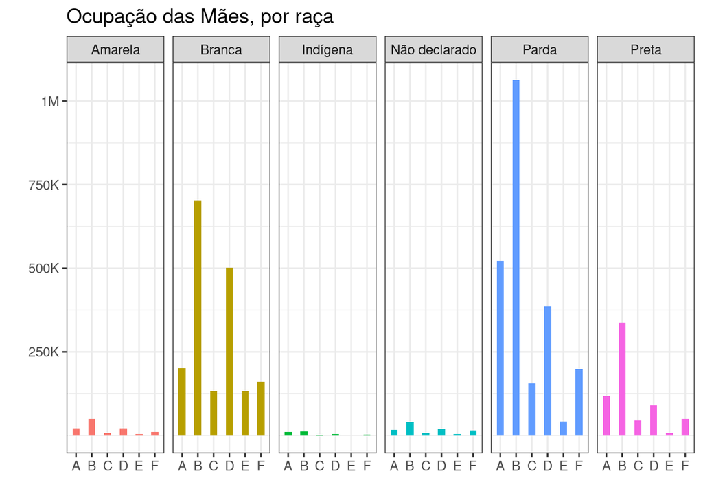

#### A - Grupo 1: Lavrador, agricultor sem empregados, bóia fria, criador de animais (gado, porcos, galinhas, ovelhas, cavalos etc.), apicultor, pescador, lenhador, seringueiro, extrativista.

#### B - Grupo 2: Diarista, empregado doméstico, cuidador de idosos, babá, cozinheiro (em casas particulares), motorista particular, jardineiro, faxineiro de empresas e prédios, vigilante, porteiro, carteiro, office-boy, vendedor, caixa, atendente de loja, auxiliar administrativo, recepcionista, servente de pedreiro, repositor de mercadoria.

#### C - Grupo 3: Padeiro, cozinheiro industrial ou em restaurantes, sapateiro, costureiro, joalheiro, torneiro mecânico, operador de máquinas, soldador, operário de fábrica, trabalhador da mineração, pedreiro, pintor, eletricista, encanador, motorista, caminhoneiro, taxista.

#### D - Grupo 4: Professor (de ensino fundamental ou médio, idioma, música, artes etc.), técnico (de enfermagem, contabilidade, eletrônica etc.), policial, militar de baixa patente (soldado, cabo, sargento), corretor de imóveis, supervisor, gerente, mestre de obras, pastor, microempresário (proprietário de empresa com menos de 10 empregados), pequeno comerciante, pequeno proprietário de terras, trabalhador autônomo ou por conta própria.

#### E - Grupo 5: Médico, engenheiro, dentista, psicólogo, economista, advogado, juiz, promotor, defensor, delegado, tenente, capitão, coronel, professor universitário, diretor em empresas públicas ou privadas, político, proprietário de empresas com mais de 10 empregados.

## Qual a renda familiar mensal dos participantes?

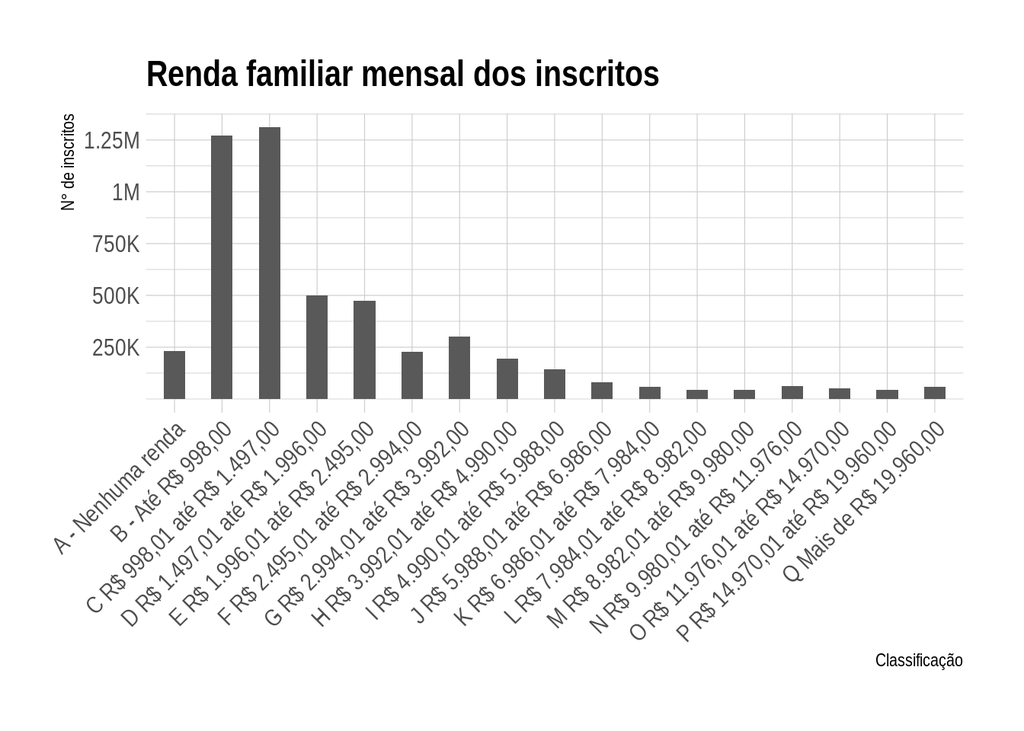

## Quantos participantes possuem um computador em casa?

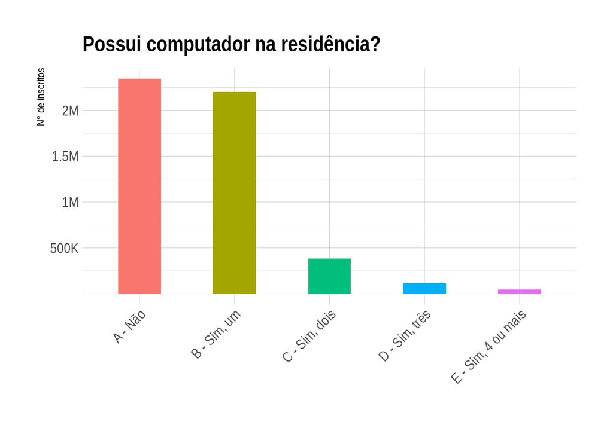

## Quantos participantes possuem acesso à internet em casa?

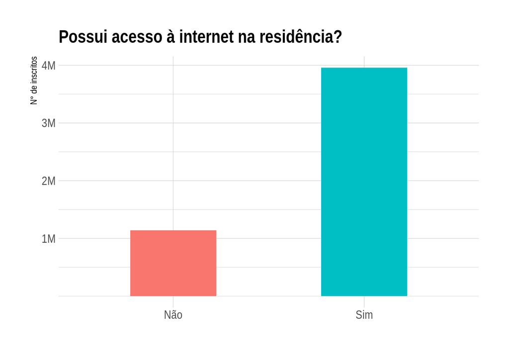

## Quantos participantes possuem um celular em casa?

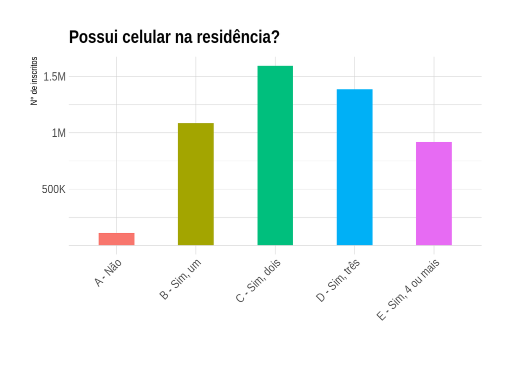

# Questões referentes às diferenças de desempenho entre os participantes:

#### Vamos usar a média das notas das provas objetivas + redação

## Qual impacto da faixa etária nas notas finais?

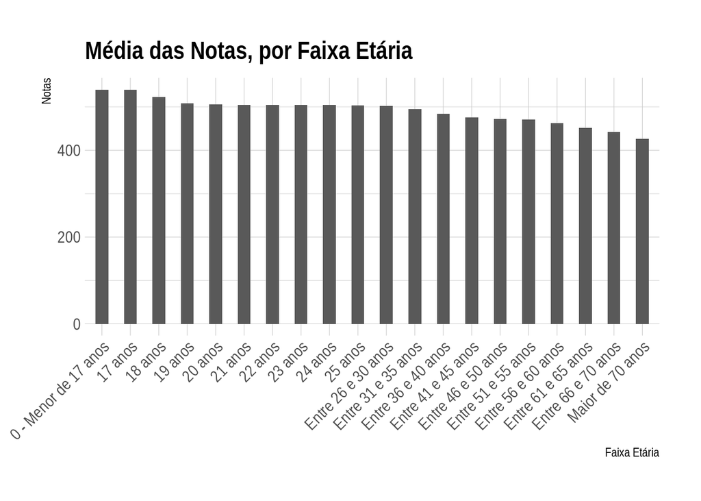

## Houve diferença significativa no desempenho entre participantes de sexos diferentes?

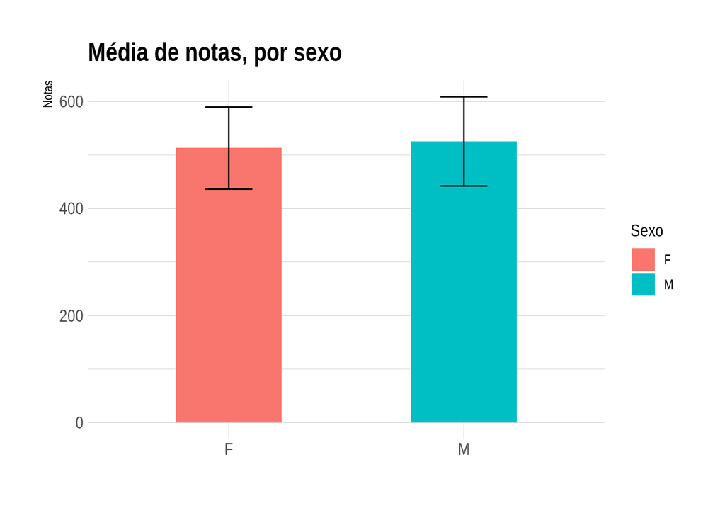

## Houve diferença diferença significativa no desempenho entre participantes de de diferentes raças?

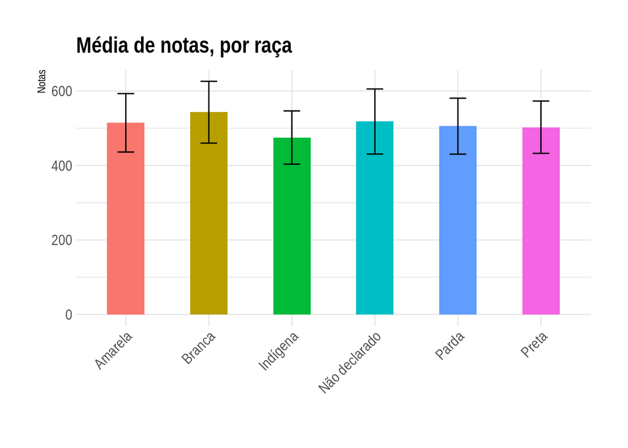

## Existem diferenças entre participantes que concluiram o ensino médio recentemente (em relação à prova) e os que já concluíram a mais tempo?

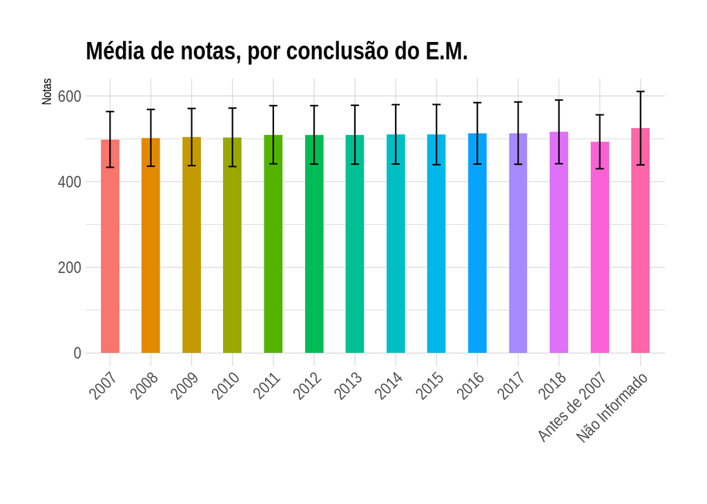

## Houve diferença significativa entre estudantes da rede pública e privada?

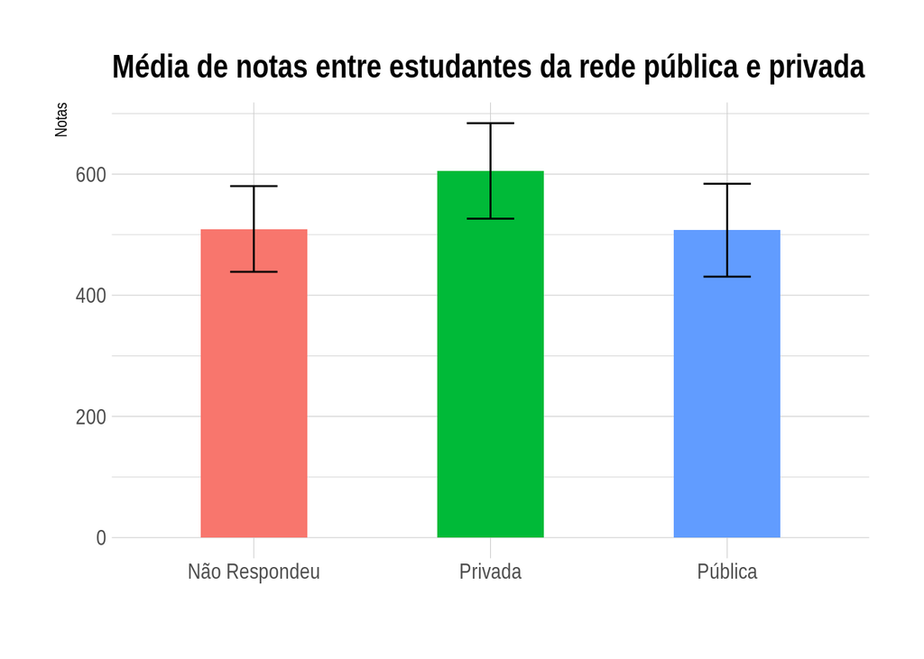

## A ocupação dos pais influencia nas notas dos participantes?

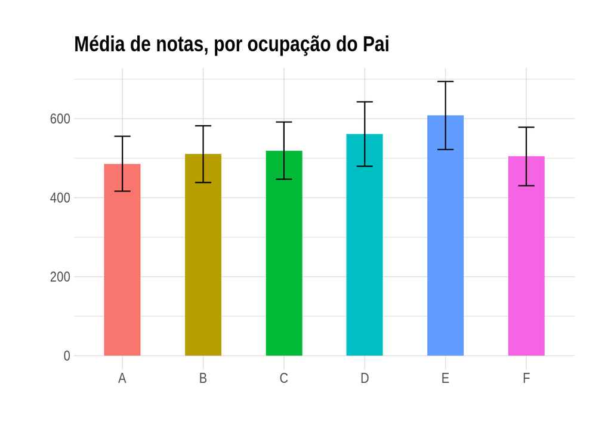

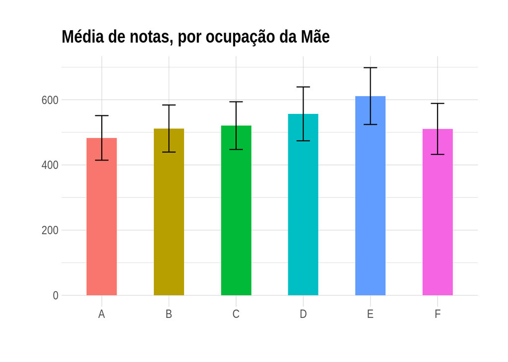

#### A - Grupo 1: Lavrador, agricultor sem empregados, bóia fria, criador de animais (gado, porcos, galinhas, ovelhas, cavalos etc.), apicultor, pescador, lenhador, seringueiro, extrativista.

#### B - Grupo 2: Diarista, empregado doméstico, cuidador de idosos, babá, cozinheiro (em casas particulares), motorista particular, jardineiro, faxineiro de empresas e prédios, vigilante, porteiro, carteiro, office-boy, vendedor, caixa, atendente de loja, auxiliar administrativo, recepcionista, servente de pedreiro, repositor de mercadoria.

#### C - Grupo 3: Padeiro, cozinheiro industrial ou em restaurantes, sapateiro, costureiro, joalheiro, torneiro mecânico, operador de máquinas, soldador, operário de fábrica, trabalhador da mineração, pedreiro, pintor, eletricista, encanador, motorista, caminhoneiro, taxista.

#### D - Grupo 4: Professor (de ensino fundamental ou médio, idioma, música, artes etc.), técnico (de enfermagem, contabilidade, eletrônica etc.), policial, militar de baixa patente (soldado, cabo, sargento), corretor de imóveis, supervisor, gerente, mestre de obras, pastor, microempresário (proprietário de empresa com menos de 10 empregados), pequeno comerciante, pequeno proprietário de terras, trabalhador autônomo ou por conta própria.

#### E - Grupo 5: Médico, engenheiro, dentista, psicólogo, economista, advogado, juiz, promotor, defensor, delegado, tenente, capitão, coronel, professor universitário, diretor em empresas públicas ou privadas, político, proprietário de empresas com mais de 10 empregados.

## Qual a diferença entre o desempenho de participantes com diferentes rendas mensais?

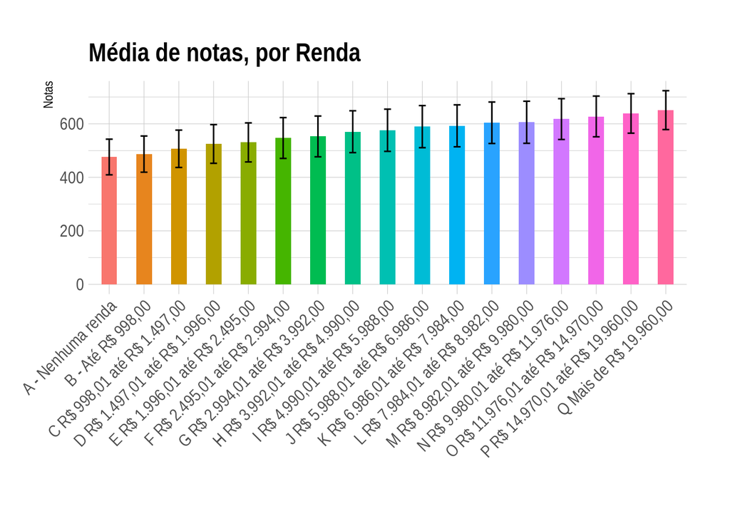